# Fonctions R en C++ et création de Package

20 juillet 2018

## Fonction R dans Rcpp

## Comment introduire une foncton R dans Rcpp

Il est possible d'utiliser des fonctions codées en R

```cpp
#include <RcppArmadillo.h>
// [[Rcpp::depends(Matrix,RcppArmadillo)]]
using namespace Rcpp;

// [[Rcpp::export]]
double runifCpp()
{
  Function runif("runif");
  return as<double>(runif(1));
}
```

## Comparaison en temps

```r
library(microbenchmark)
library(ggplot2)

tm <- microbenchmark(runif(1),runifCpp(),times=1000L)
```

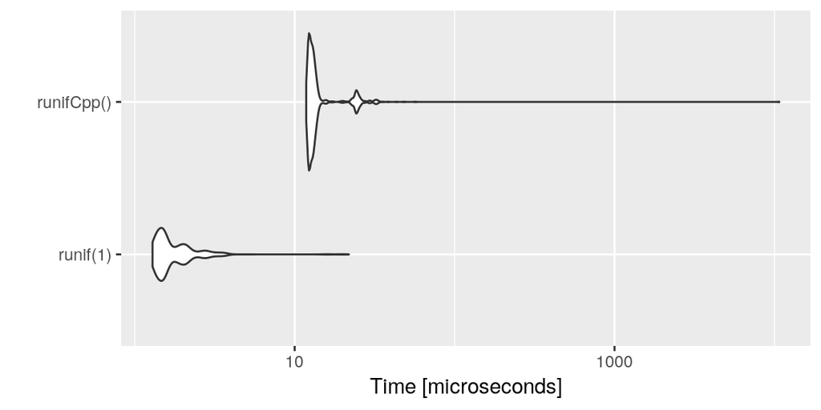

```r
autoplot(tm)
```

## Constat

L'utilisation de fonction codées en R comme runif, rnorm ou autre vont être plus longues à tourner si elles sont implémentées en C++. Il s'agit de fonctions déjà implémentées en C qui sont sont déjà rapides en R.

```cpp
#include <RcppArmadillo.h>
// [[Rcpp::depends(Matrix,RcppArmadillo)]]
using namespace Rcpp;
using namespace arma;

// [[Rcpp::export]]
double runifCpp2()
{
  return randu();
}
```

## Nouvelle comparaison

```r
tm <- microbenchmark(runif(1),runifCpp(),runifCpp2(),times=1000L)
```

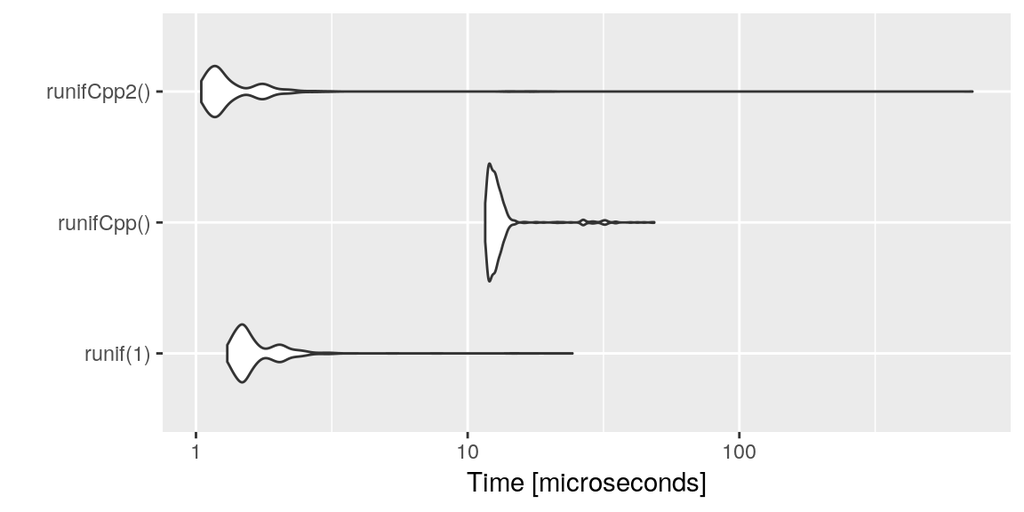

```r
autoplot(tm)
```

## L'importation de fonctions R

L'importation de fonction R est donc à utiliser avec parcimonie et doit se limiter qu'à certains cas :

- une fonction R à structure complexe et difficilement transposable
- dans un package R, utilisation de fonctions qui sont modifiées en fonction du contexte

## Exercice

## Exercice

1. Importer la fonction `optim` de R dans une fonction `optimisation` C++
2. Réécrire la fonction de vraissemblance en C++ pour ne prendre que theta en entrée (`randn` à utiliser)
3. Faire l'optimisation de la vraissemblance (sans descente de gradient) avec la fonction `optimisation`
4. À l'aide du package microbenchmark comparer les temps de l'optimisation en R et en C++

## Correction

## Optimisation

```cpp
#include "RcppArmadillo.h"
// [[Rcpp::depends(RcppArmadillo)]]
using namespace arma;
using namespace Rcpp;

double norme2(vec x) {
  return as_scalar(sqrt(sum(pow(x,2))));
}

// [[Rcpp::export]]
double frCpp(vec theta) {
  vec X = (randn(1000)+1)/2;
  const double pi = 3.141592653589793238462643383280;
  int n = X.n_elem;
  double m = theta[0];
  double sigma2 = theta[1];
  return -( -(n/2)*log(sigma2*2*pi) - pow(norme2(X-m),2)/(2*sigma2) );
}
```

## Optimisation

```cpp
#include "RcppArmadillo.h"
// [[Rcpp::depends(RcppArmadillo)]]
using namespace arma;
using namespace Rcpp;

// [[Rcpp::export]]
vec optimisation(vec thetaInit, Function fn){
  Function optim("optim");
  List resOpt = as<List>(optim(thetaInit,fn));
  return resOpt["par"];
}
```

## Optimisation

```r
optimisation(c(0,1),frCpp)
```

```
##           [,1]
## [1,] 0.5703562
## [2,] 0.3068187
```

## Optimisation

```r
tm <- microbenchmark(optimisation(c(0,1),frCpp),optim(c(0,1),fr),times=1000L)
```

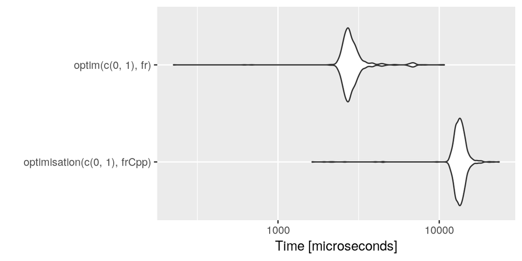

```r
autoplot(tm)
```

## Rcpp dans un Package R

## Utiliser Rcpp dans un package

Dans un package R utiliser la fonction de `devtools`

```r
devtools::use_rcpp()
```

Le lancement de cette fonction :

- génère un dossier `src`
- fait les modifications nécessaires dans le fichier DESCRIPTION
- créer un fichier `.gitignore` (si le gestionnaire de version `git` est utilisé)

## Dans le dossier `src`

Le code C++ doit se situer dans le dossier `src`. (Fichier > Nouveau > Fichier C++)

Les parties chronophages du package doivent être implémentées dans un fichier dans lequel les fonctions utiles sont exportées par `[[Rcpp::export]]`.

La documentation de fonction Rcpp est aussi gérée par `Roxygen`

## Exercice

## Exercice

1. Créer un nouveau package appelé `optimisation`
2. Lancer la commande `devtools::use_rcpp()`
3. Copier les fonctions de vraissemblance dans un nouveau fichier C++
4. Construire le package (Ctrl+Maj+b)
5. Tester la fonction `optimisation` du package dans R